# Text Mining for R

Iheb Jridi

## Text Mining - Apple Product

**Problem**

Apple is considered today as the largest manufacturer of electronic products and software .

In fact, the company’s market capitalization exceeded trillion dollars in August 2018.

The apple company builds high-performance luxury computer equipment: the iPhone for example, sells at 590 units per minute.

It will be interesting to find out what people think of this company, by finding the most appropriate words associated with the term **Apple**. The problem therefore comes down to finding the theme of the flow of comments from Internet users (Twitter in our case).

Given the size of content to be studied, the task turns out to be difficult.

The use of text mining is therefore paramount.

# Presentation of the proposed solution

Multiple text mining methods exist and allow to identify the theme of a textual data flow. In this lab, we will focus on the cloud keywords (better known as **WordCloud**).

The keyword cloud is a visual representation of the keywords most used in a data flow.

Generally, words are displayed in font sizes and weights that are more visible when they are so used or popular (so depending on their frequency of appearance).

**Technical Details**

In this part, we will carefully explain the procedure to do. The operation consists of 3 main stages

**Imports**

```r
library("NLP")
library ("tm")
library("wordcloud")
library ("RColorBrewer")
```

**Loading data**

```r
data <-  readLines("apple.txt")
```

**Corpus Creation**

A corpus is a large and structured set of textual data. The purpose of this step is to convert semi-structured data into structured data that is easy to clean and handle.

```r
docs <- Corpus ( VectorSource (data))
```

**Cleaning and Transforming**

The transformation and cleaning stage consists of: * The removal of stopwords * The removal of punctuations * The deletion of figures * The deletion of spaces * Removal of special characters * The universalization of the case (in miniscule)

In our case, we will also delete the word apple, for more meaningful results.

```r
toSpace <- content_transformer ( function (x , pattern ) gsub (pattern, "", x))
docs <- tm_map (docs, content_transformer (tolower))
```

Text Processing

```r
# Supprimer les stopwords
docs <- tm_map (docs,removeWords, stopwords ("english"))

# Supprimer les ponctuations
docs <- tm_map (docs, removePunctuation)

# Supprimer les chiffres
docs <- tm_map (docs, removeNumbers)

# Réduire les espaces
docs <- tm_map (docs, stripWhitespace)
```

```r
docs <- tm_map (docs, toSpace, "\n")


docs <- tm_map (docs, toSpace, "\t")

docs <- tm_map (docs, toSpace, "@")

docs <- tm_map (docs, toSpace, "apple")


docs <- tm_map (docs, toSpace, "#")


docs <- tm_map(docs, toSpace, "http")
```

**Construction of the word matrix**

The *TermDocumentMatrix* function takes the corpus as a parameter and allows you to create the matrix.

Then, we sort the matrix in decreasing order of frequencies and we create a dataframe from of the sorted matrix. This dataframe will ultimately allow you to create the wordcloud.

```r
dtm <- TermDocumentMatrix (docs)
m <- as.matrix(dtm)
v <- sort( rowSums (m),decreasing=TRUE)
d <- data.frame(word = names (v),freq=v)
```

**20 most frequent words**

```r
findFreqTerms(dtm, lowfreq = 20)
```

```
##  [1] "iphone"               "iphones"              "new"
##  [4] "phone"                "can"                  "one"
##  [7] "will"                 "get"                  "ios"
## [10] "just"                 "iphonec"              "store"
## [13] "now"                  "app"                  "ipad"
## [16] "itunes"               "ipod"                 "ipodplayerpromo"
## [19] "itune"                "promoipodplayerpromo"
```

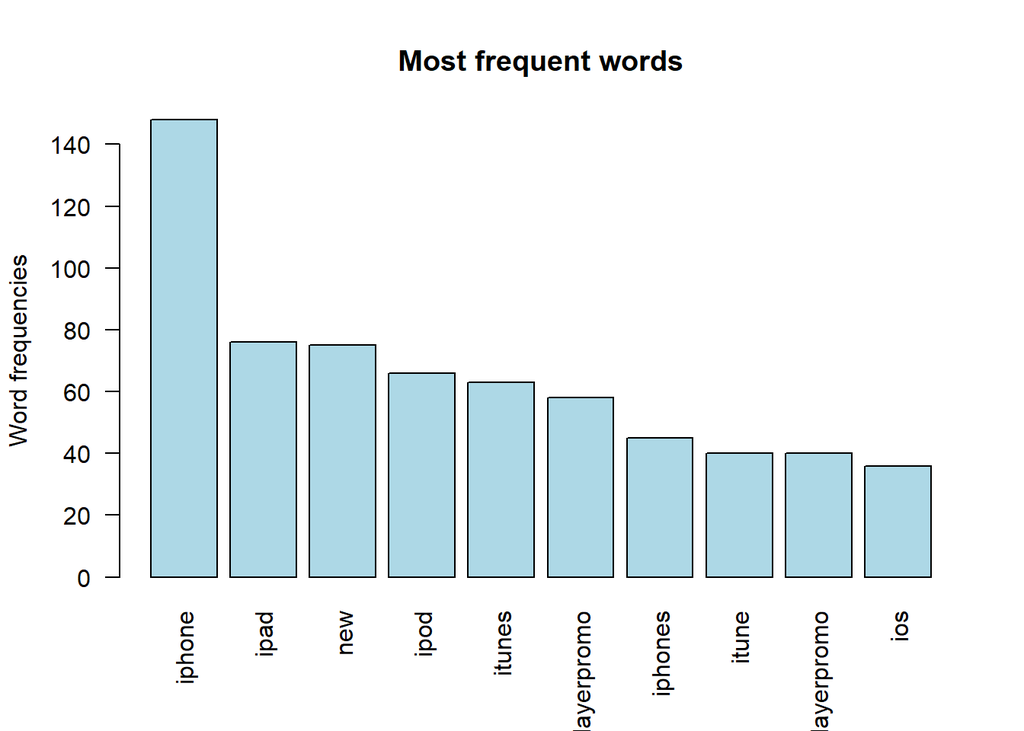

```r
barplot(d[1:10,]$freq, las = 2, names.arg = d[1:10,]$word,
col ="lightblue", main ="Most frequent words",
ylab = "Word frequencies")
```

**Results**

**Words associated with Apple**

```r
dtm
```

```
## <<TermDocumentMatrix (terms: 2493, documents: 689)>>
## Non-/sparse entries: 4983/1712694
## Sparsity           : 100%
## Maximal term length: 33
## Weighting          : term frequency (tf)
```

```r
findAssocs (dtm, terms = c("apple","phone","new"), corlimit = c(0.1,0.3,0.2))
```

```
## $apple
## numeric(0)
##
## $phone
##       legit replacement   wednesday
##        0.36        0.36        0.36
##
## $new
##                   bravo                 checked                   specs
##                    0.22                    0.22                    0.22
##                becoming              dominating smgtechmediacompageshtm
##                    0.22                    0.22                    0.22
##                  actual                exciting                   delay
##                    0.22                    0.22                    0.22
```

**WordCloud**

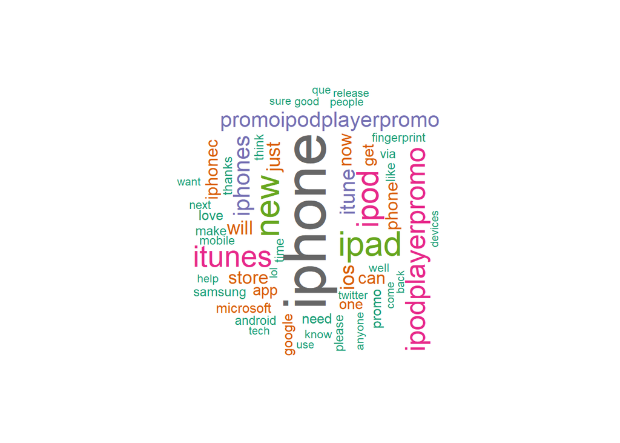

```r
set.seed (1234)
wordcloud(words = d$word, freq = d$freq, min.freq = 10,
max.words=200, random.order=FALSE, rot.per=0.35,
colors= brewer.pal(8, "Dark2"))
```

**Interpretations**

It is also important to mention that the term **iPhone** has the highest frequency.

This explains the success of this smartphone which is *always* the news.